# ▒ 연관규칙분석 ▒

### **0. 환경설정**

```r
# install.packages("arules")
# install.packages("arulesViz")
library(arules)
library(arulesViz)
```

### **1. 데이터 설명 : Adult data**

**(Q) 어떤 규칙을 갖는 사람들이 남성일까?**  
**[데이터 호출]**

```r
data(Adult)
summary(Adult)
```

```
## transactions as itemMatrix in sparse format with
##  48842 rows (elements/itemsets/transactions) and
##  115 columns (items) and a density of 0.1089939
##
## most frequent items:
##            capital-loss=None            capital-gain=None
##                        46560                        44807
## native-country=United-States                   race=White
##                        43832                        41762
##            workclass=Private                      (Other)
##                        33906                       401333
##
## element (itemset/transaction) length distribution:
## sizes
##     9    10    11    12    13
##    19   971  2067 15623 30162
##
##    Min. 1st Qu.  Median    Mean 3rd Qu.    Max.
##    9.00   12.00   13.00   12.53   13.00   13.00
##
## includes extended item information - examples:
##            labels variables      levels
## 1       age=Young       age       Young
## 2 age=Middle-aged       age Middle-aged
## 3      age=Senior       age      Senior
##
## includes extended transaction information - examples:
##   transactionID
## 1             1
## 2             2
## 3             3
```

**[막대 그래프]** 지지도(support)가 0.4이상인 item들의 빈도

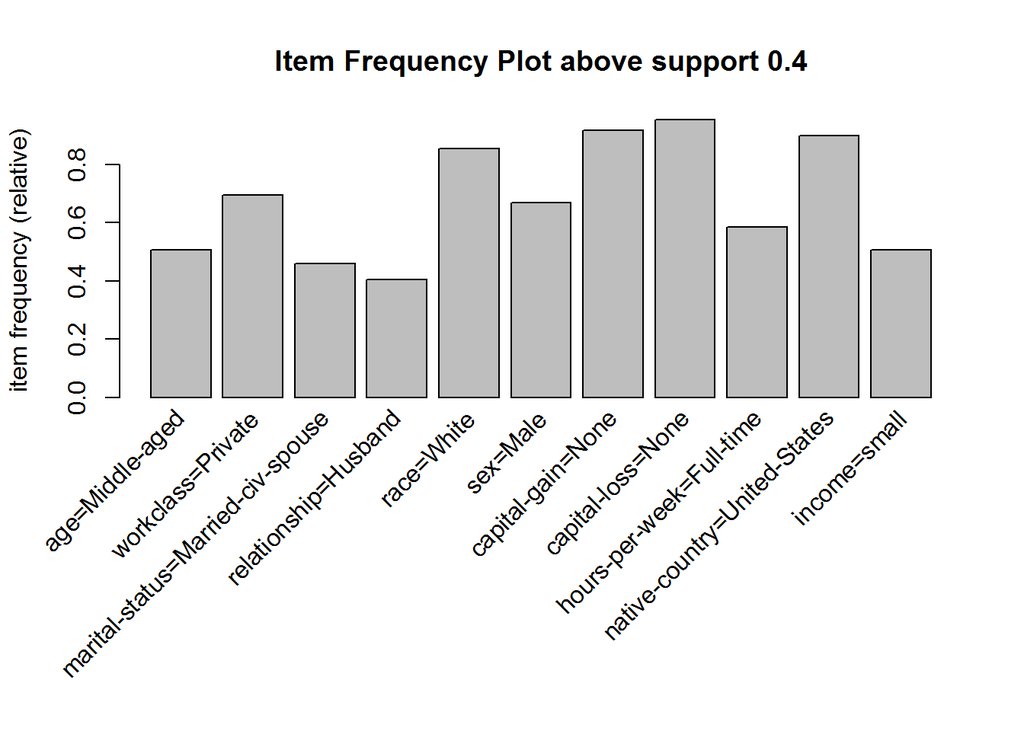

```r
itemFrequencyPlot(Adult, support = 0.4, main = "Item Frequency Plot above support 0.4")
```

**[막대 그래프]** 지지도(support) 기준 상위 10개 item들의 빈도

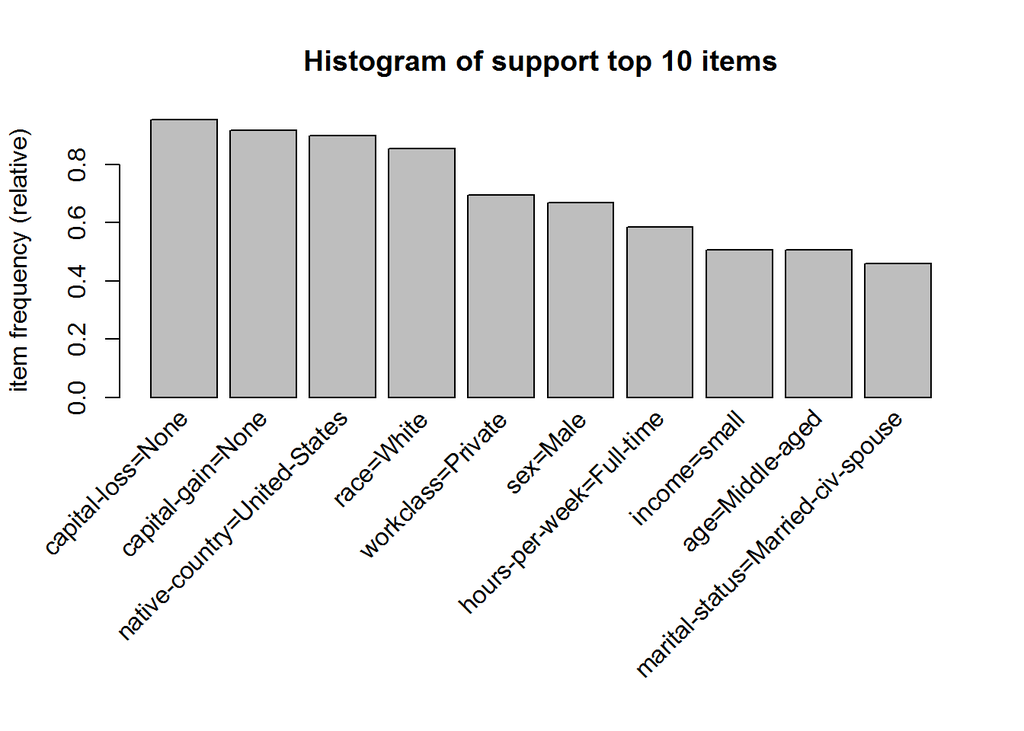

```r
itemFrequencyPlot(Adult, topN = 10, main = "Histogram of support top 10 items")
```

### **2. 연관규칙분석**

**[연관 규칙]** 지지도가 0.4 이상인 경우

```r
rules                 <- apriori(Adult, parameter = list(support = 0.4))
```

```
## Apriori
##
## Parameter specification:
##  confidence minval smax arem  aval originalSupport maxtime support minlen
##         0.8    0.1    1 none FALSE            TRUE       5     0.4      1
##  maxlen target  ext
##      10  rules TRUE
##
## Algorithmic control:
##  filter tree heap memopt load sort verbose
##     0.1 TRUE TRUE  FALSE TRUE    2    TRUE
##
## Absolute minimum support count: 19536
##
## set item appearances ...[0 item(s)] done [0.00s].
## set transactions ...[115 item(s), 48842 transaction(s)] done [0.05s].
## sorting and recoding items ... [11 item(s)] done [0.00s].
## creating transaction tree ... done [0.03s].
## checking subsets of size 1 2 3 4 5 done [0.00s].
## writing ... [169 rule(s)] done [0.00s].
## creating S4 object  ... done [0.00s].
```

```r
summary(rules)
```

```
## set of 169 rules
##
## rule length distribution (lhs + rhs):sizes
##  1  2  3  4  5
##  4 40 74 43  8
##
##    Min. 1st Qu.  Median    Mean 3rd Qu.    Max.
##   1.000   2.000   3.000   3.065   4.000   5.000
##
## summary of quality measures:
##     support         confidence        coverage           lift
##  Min.   :0.4013   Min.   :0.8209   Min.   :0.4034   Min.   :0.9594
##  1st Qu.:0.4366   1st Qu.:0.8871   1st Qu.:0.4849   1st Qu.:0.9916
##  Median :0.4994   Median :0.9129   Median :0.5564   Median :0.9992
##  Mean   :0.5421   Mean   :0.9120   Mean   :0.5956   Mean   :1.0399
##  3rd Qu.:0.5897   3rd Qu.:0.9471   3rd Qu.:0.6640   3rd Qu.:1.0169
##  Max.   :0.9533   Max.   :0.9999   Max.   :1.0000   Max.   :2.4529
##      count
##  Min.   :19602
##  1st Qu.:21325
##  Median :24392
##  Mean   :26479
##  3rd Qu.:28803
##  Max.   :46560
##
## mining info:
##   data ntransactions support confidence
##  Adult         48842     0.4        0.8
```

**[연관 규칙]** 지지도가 0.4이상이면서 향상도가 1.3 이상인 경우

```r
rules.sub             <- subset(rules, subset = rhs %pin% "sex" & lift > 1.3)
inspect(sort(rules.sub)[1:3])
```

```
##     lhs                                    rhs          support confidence  coverage     lift count
## [1] {marital-status=Married-civ-spouse} => {sex=Male} 0.4074157  0.8891818 0.4581917 1.330151 19899
## [2] {relationship=Husband}              => {sex=Male} 0.4036485  0.9999493 0.4036690 1.495851 19715
## [3] {marital-status=Married-civ-spouse,
##      relationship=Husband}              => {sex=Male} 0.4034028  0.9999492 0.4034233 1.495851 19703
```

→ 위 결과로는 “시민권자와 결혼하였으면 남성이다.” , “남편이면 남성이다”, “시민권자와 결혼했고 남편이면 남성이다.”라는 것들을 찾음

**[시각화]** 모든 규칙의 산점도

- x축: 지지도
- y축: 향상도
- 점의 색: 신뢰도

```
## To reduce overplotting, jitter is added! Use jitter = 0 to prevent jitter.
```

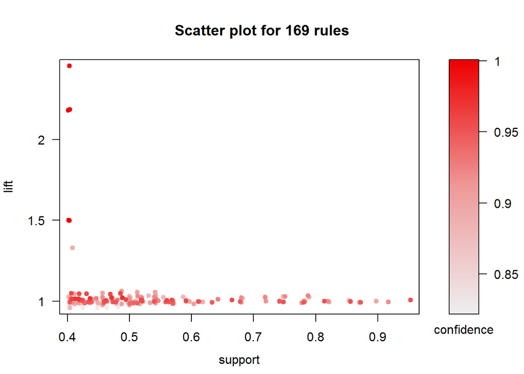

```r
plot(rules, measure = c("support", "lift"), shading = "confidence")
```

**[시각화]** 같은 그래프를 3D로 표현

※ control=list(reorder=TRUE) 옵션: 아이템들을 재배열 → 군집효과를 두드러지게 함  
※ 옵션이 적용되지 않아 우선 주석처리해둠

```
## Itemsets in Antecedent (LHS)
##  [1] "{marital-status=Married-civ-spouse,sex=Male}"
##  [2] "{relationship=Husband,sex=Male}"
##  [3] "{relationship=Husband}"
##  [4] "{marital-status=Married-civ-spouse,relationship=Husband}"
##  [5] "{marital-status=Married-civ-spouse}"
##  [6] "{sex=Male,capital-gain=None,capital-loss=None,native-country=United-States}"
##  [7] "{capital-loss=None,native-country=United-States,income=small}"
##  [8] "{native-country=United-States,income=small}"
##  [9] "{race=White,income=small}"
## [10] "{workclass=Private,capital-gain=None,capital-loss=None,native-country=United-States}"
## [11] "{race=White,capital-gain=None,capital-loss=None}"
## [12] "{race=White,sex=Male,capital-gain=None,capital-loss=None}"
## [13] "{sex=Male,capital-gain=None,native-country=United-States}"
## [14] "{capital-gain=None,capital-loss=None,native-country=United-States}"
```

[output cut: 70 more lines]

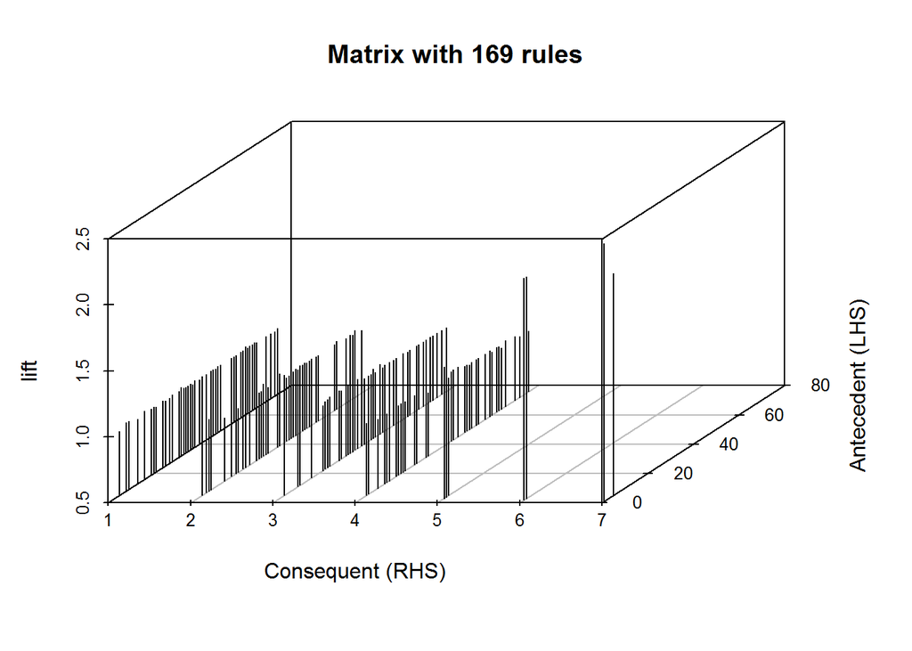

```r
# plot(rules, method = "matrix3D", measure = "lift", control = list(reorder = TRUE))
plot(rules, method = "matrix3D", measure = "lift")
```

**[시각화]** 향상도 기준 상위 10개의 연관 규칙 시각화

- 색깔: 향상도의 크기
- 원의 크기: 지지도의 크기

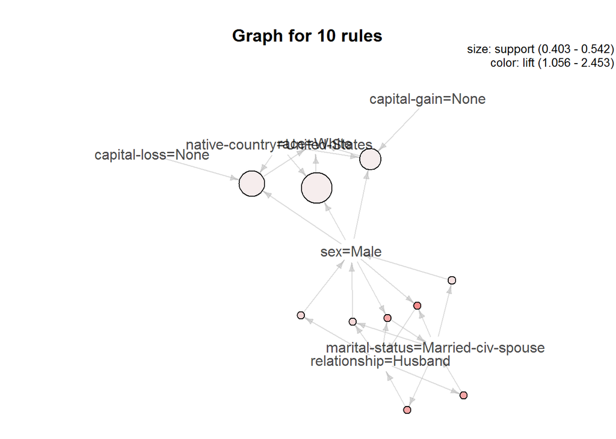

```r
subrules2             <- head(sort(rules, by = "lift"), 10)
plot(subrules2, method = "graph")
```